# Part I - Ford Gobike Data Exploration

## by Teniola Alade

## Introduction

This data set includes information about individual rides made in a bike-sharing system covering the greater San Francisco Bay area in the year 2019.

## Preliminary Wrangling

```python
# import all packages and set plots to be embedded inline
import numpy as np
import pandas as pd
import matplotlib.pyplot as plt
import seaborn as sb

%matplotlib inline
```

# GATHERING DATASET

```python
ford_gobike = pd.read_csv('201902-fordgobike-tripdata.csv')
```

# ASSESSING DATA

```python
ford_gobike.sample(5)
```

|  | duration_sec | start_time | end_time | start_station_id | start_station_name | start_station_latitude | start_station_longitude | end_station_id | end_station_name | end_station_latitude | end_station_longitude | bike_id | user_type | member_birth_year | member_gender | bike_share_for_all_trip |
| --- | --- | --- | --- | --- | --- | --- | --- | --- | --- | --- | --- | --- | --- | --- | --- | --- |
| 62179 | 257 | 2019-02-20 17:12:38.6380 | 2019-02-20 17:16:56.2440 | 100.0 | Bryant St at 15th St | 37.767100 | -122.410662 | 77.0 | 11th St at Natoma St | 37.773507 | -122.416040 | 5911 | Subscriber | 1968.0 | Female | No |
| 67917 | 1328 | 2019-02-20 06:58:52.5410 | 2019-02-20 07:21:01.0810 | 138.0 | Jersey St at Church St | 37.750900 | -122.427411 | 81.0 | Berry St at 4th St | 37.775880 | -122.393170 | 5045 | Subscriber | 1980.0 | Female | No |
| 76003 | 834 | 2019-02-19 08:34:31.5400 | 2019-02-19 08:48:25.8710 | 122.0 | 19th St at Mission St | 37.760299 | -122.418892 | 50.0 | 2nd St at Townsend St | 37.780526 | -122.390288 | 4977 | Subscriber | 1988.0 | Male | No |
| 150071 | 437 | 2019-02-06 18:31:25.6250 | 2019-02-06 18:38:43.2520 | 245.0 | Downtown Berkeley BART | 37.870139 | -122.268422 | 239.0 | Bancroft Way at Telegraph Ave | 37.868813 | -122.258764 | 262 | Subscriber | 1991.0 | Male | No |
| 153526 | 158 | 2019-02-06 12:29:35.8880 | 2019-02-06 12:32:14.7510 | 343.0 | Bryant St at 2nd St | 37.783172 | -122.393572 | 66.0 | 3rd St at Townsend St | 37.778742 | -122.392741 | 5401 | Subscriber | NaN | NaN | No |

```python
# Overview of data
ford_gobike.info()
```

```
<class 'pandas.core.frame.DataFrame'>
RangeIndex: 183412 entries, 0 to 183411
Data columns (total 16 columns):
 #   Column                   Non-Null Count   Dtype
---  ------                   --------------   -----
 0   duration_sec             183412 non-null  int64
 1   start_time               183412 non-null  object
 2   end_time                 183412 non-null  object
 3   start_station_id         183215 non-null  float64
 4   start_station_name       183215 non-null  object
 5   start_station_latitude   183412 non-null  float64
 6   start_station_longitude  183412 non-null  float64
 7   end_station_id           183215 non-null  float64
 8   end_station_name         183215 non-null  object
 9   end_station_latitude     183412 non-null  float64
 10  end_station_longitude    183412 non-null  float64
 11  bike_id                  183412 non-null  int64
 12  user_type                183412 non-null  object
 13  member_birth_year        175147 non-null  float64
 14  member_gender            175147 non-null  object
 15  bike_share_for_all_trip  183412 non-null  object
dtypes: float64(7), int64(2), object(7)
memory usage: 22.4+ MB
```

```python
# descriptive statistics
ford_gobike.describe()
```

|  | duration_sec | start_station_id | start_station_latitude | start_station_longitude | end_station_id | end_station_latitude | end_station_longitude | bike_id | member_birth_year |
| --- | --- | --- | --- | --- | --- | --- | --- | --- | --- |
| count | 183412.000000 | 183215.000000 | 183412.000000 | 183412.000000 | 183215.000000 | 183412.000000 | 183412.000000 | 183412.000000 | 175147.000000 |
| mean | 726.078435 | 138.590427 | 37.771223 | -122.352664 | 136.249123 | 37.771427 | -122.352250 | 4472.906375 | 1984.806437 |
| std | 1794.389780 | 111.778864 | 0.099581 | 0.117097 | 111.515131 | 0.099490 | 0.116673 | 1664.383394 | 10.116689 |
| min | 61.000000 | 3.000000 | 37.317298 | -122.453704 | 3.000000 | 37.317298 | -122.453704 | 11.000000 | 1878.000000 |
| 25% | 325.000000 | 47.000000 | 37.770083 | -122.412408 | 44.000000 | 37.770407 | -122.411726 | 3777.000000 | 1980.000000 |
| 50% | 514.000000 | 104.000000 | 37.780760 | -122.398285 | 100.000000 | 37.781010 | -122.398279 | 4958.000000 | 1987.000000 |
| 75% | 796.000000 | 239.000000 | 37.797280 | -122.286533 | 235.000000 | 37.797320 | -122.288045 | 5502.000000 | 1992.000000 |
| max | 85444.000000 | 398.000000 | 37.880222 | -121.874119 | 398.000000 | 37.880222 | -121.874119 | 6645.000000 | 2001.000000 |

```python
# Null values
ford_gobike.isnull().sum(), ford_gobike.isnull().sum().sum()
```

```
(duration_sec                  0
 start_time                    0
 end_time                      0
 start_station_id            197
 start_station_name          197
 start_station_latitude        0
 start_station_longitude       0
 end_station_id              197
 end_station_name            197
 end_station_latitude          0
 end_station_longitude         0
 bike_id                       0
 user_type                     0
 member_birth_year          8265
 member_gender              8265
 bike_share_for_all_trip       0
 dtype: int64,
 17318)
```

```python
# duplicates
ford_gobike.duplicated().sum()
```

```
0
```

```python
# Unique values
ford_gobike['user_type'].unique(), ford_gobike['member_gender'].unique(), ford_gobike['bike_share_for_all_trip'].unique()
```

```
(array(['Customer', 'Subscriber'], dtype=object),
 array(['Male', nan, 'Other', 'Female'], dtype=object),
 array(['No', 'Yes'], dtype=object))
```

```python
# Number of unique bikes
ford_gobike.bike_id.nunique()
```

```
4646
```

```python
# dataset dimension
ford_gobike.shape
```

```
(183412, 16)
```

## CLEANING

The dataset consists of a few missing data in terms of null values and erroneous datatypes - 'start_time', 'end_time','bike_share_for_all_trip' , 'member_birth_year', it also requires the addition/renaming of some columns and removal of some unnecessary columns.

```python
# Copy of original dataset
ford_gobike_clean = ford_gobike.copy()
```

```python
# Dropping null values
ford_gobike_clean.dropna(inplace=True)
ford_gobike_clean.isnull().sum()
```

```
duration_sec               0
start_time                 0
end_time                   0
start_station_id           0
start_station_name         0
start_station_latitude     0
start_station_longitude    0
end_station_id             0
end_station_name           0
end_station_latitude       0
end_station_longitude      0
bike_id                    0
user_type                  0
member_birth_year          0
member_gender              0
bike_share_for_all_trip    0
dtype: int64
```

```python
# Changing datatypes to datetime
ford_gobike_clean['start_time']=pd.to_datetime(ford_gobike_clean['start_time'])
ford_gobike_clean['end_time']=pd.to_datetime(ford_gobike_clean['end_time'])
```

```python
# adding new columns
ford_gobike_clean['start_year'] = ford_gobike_clean.start_time.dt.year
ford_gobike_clean['start_month'] = ford_gobike_clean.start_time.dt.month_name()
ford_gobike_clean['start_day'] = ford_gobike_clean.start_time.dt.day_name()
ford_gobike_clean['start_day_id'] = ford_gobike_clean.start_time.dt.day_of_week
ford_gobike_clean['start_hour'] = ford_gobike_clean.start_time.dt.hour


ford_gobike_clean['end_month'] = ford_gobike_clean.end_time.dt.month_name()
ford_gobike_clean['end_day'] = ford_gobike_clean.end_time.dt.day_name()
ford_gobike_clean['end_day_id'] = ford_gobike_clean.end_time.dt.day_of_week
ford_gobike_clean['end_hour'] = ford_gobike_clean.end_time.dt.hour
```

```python
# converting to string
ford_gobike_clean.bike_id = ford_gobike_clean.bike_id.astype(str)
```

```python
# changing datatype to boolean
ford_gobike_clean.bike_share_for_all_trip = ford_gobike_clean.bike_share_for_all_trip.map({'Yes': True, 'No': False})
```

```python
# Adding column and changing datatype
ford_gobike_clean['age']= (ford_gobike_clean.start_year - ford_gobike_clean['member_birth_year']).astype(int)
```

```python
# Renaming column name
ford_gobike_clean.rename(columns = {'member_gender':'gender'}, inplace=True)
```

```python
# Dropping a few columns
ford_gobike_clean.drop(['start_station_id','end_station_id','start_station_longitude','start_station_latitude','end_station_longitude','end_station_latitude','member_birth_year'],axis=1,inplace=True)
```

```python
# Unique values
ford_gobike_clean['user_type'].unique(), ford_gobike_clean['gender'].unique(), ford_gobike_clean['bike_share_for_all_trip'].unique()
```

```
(array(['Customer', 'Subscriber'], dtype=object),
 array(['Male', 'Other', 'Female'], dtype=object),
 array([False,  True]))
```

```python
ford_gobike_clean.dtypes
```

```
duration_sec                        int64
start_time                 datetime64[ns]
end_time                   datetime64[ns]
start_station_name                 object
end_station_name                   object
bike_id                            object
user_type                          object
gender                             object
bike_share_for_all_trip              bool
start_year                          int64
start_month                        object
start_day                          object
start_day_id                        int64
start_hour                          int64
end_month                          object
end_day                            object
end_day_id                          int64
end_hour                            int64
age                                 int32
dtype: object
```

```python
ford_gobike_clean.head()
```

|  | duration_sec | start_time | end_time | start_station_name | end_station_name | bike_id | user_type | gender | bike_share_for_all_trip | start_year | start_month | start_day | start_day_id | start_hour | end_month | end_day | end_day_id | end_hour | age |
| --- | --- | --- | --- | --- | --- | --- | --- | --- | --- | --- | --- | --- | --- | --- | --- | --- | --- | --- | --- |
| 0 | 52185 | 2019-02-28 17:32:10.145 | 2019-03-01 08:01:55.975 | Montgomery St BART Station (Market St at 2nd St) | Commercial St at Montgomery St | 4902 | Customer | Male | False | 2019 | February | Thursday | 3 | 17 | March | Friday | 4 | 8 | 35 |
| 2 | 61854 | 2019-02-28 12:13:13.218 | 2019-03-01 05:24:08.146 | Market St at Dolores St | Powell St BART Station (Market St at 4th St) | 5905 | Customer | Male | False | 2019 | February | Thursday | 3 | 12 | March | Friday | 4 | 5 | 47 |
| 3 | 36490 | 2019-02-28 17:54:26.010 | 2019-03-01 04:02:36.842 | Grove St at Masonic Ave | Central Ave at Fell St | 6638 | Subscriber | Other | False | 2019 | February | Thursday | 3 | 17 | March | Friday | 4 | 4 | 30 |
| 4 | 1585 | 2019-02-28 23:54:18.549 | 2019-03-01 00:20:44.074 | Frank H Ogawa Plaza | 10th Ave at E 15th St | 4898 | Subscriber | Male | True | 2019 | February | Thursday | 3 | 23 | March | Friday | 4 | 0 | 45 |
| 5 | 1793 | 2019-02-28 23:49:58.632 | 2019-03-01 00:19:51.760 | 4th St at Mission Bay Blvd S | Broadway at Kearny | 5200 | Subscriber | Male | False | 2019 | February | Thursday | 3 | 23 | March | Friday | 4 | 0 | 60 |

```python
ford_gobike_clean.to_csv('ford_gobike_clean',index=False);
```

### What is/are the main feature(s) of interest in your dataset?

I'm most interested in figuring out what features are best for predicting the duration of the ford_gobike rides in the dataset.

### What features in the dataset do you think will help support your investigation into your feature(s) of interest?

I expect that the duration of the trip is mostly affected by the age of the user, the day of the week, gender and by the user type; subscriber or member

## Univariate Exploration

## Daily Usage.

```python
ford_gobike_clean.start_day = ford_gobike_clean.start_day.astype('category')
```

```python
def x_y_t(xl,yl,title):
    plt.title(title,size = 15)
    plt.xlabel(xl,size = 15)
    plt.ylabel(yl,size = 15)
```

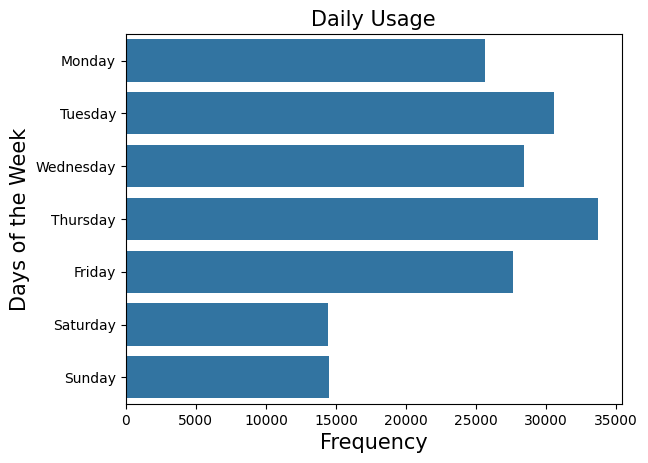

```python
base_color = sb.color_palette()[0];
sb.countplot(data=ford_gobike_clean, y='start_day_id', color = base_color);
plt.yticks([0,1,2,3,4,5,6],['Monday', 'Tuesday','Wednesday','Thursday','Friday','Saturday', 'Sunday']);
x_y_t('Frequency','Days of the Week','Daily Usage')
```

The plot above shows that more users rode on Thursdays and Tuesdays, with a significant decrease on the weekends.

# Trip Duration

```python
ford_gobike_clean.describe()
```

|  | duration_sec | start_year | start_day_id | start_hour | end_day_id | end_hour | age |
| --- | --- | --- | --- | --- | --- | --- | --- |
| count | 174952.000000 | 174952.0 | 174952.000000 | 174952.000000 | 174952.000000 | 174952.000000 | 174952.000000 |
| mean | 704.002744 | 2019.0 | 2.619953 | 13.456165 | 2.620090 | 13.609533 | 34.196865 |
| std | 1642.204905 | 0.0 | 1.808470 | 4.734282 | 1.808667 | 4.748029 | 10.118731 |
| min | 61.000000 | 2019.0 | 0.000000 | 0.000000 | 0.000000 | 0.000000 | 18.000000 |
| 25% | 323.000000 | 2019.0 | 1.000000 | 9.000000 | 1.000000 | 9.000000 | 27.000000 |
| 50% | 510.000000 | 2019.0 | 3.000000 | 14.000000 | 3.000000 | 14.000000 | 32.000000 |
| 75% | 789.000000 | 2019.0 | 4.000000 | 17.000000 | 4.000000 | 18.000000 | 39.000000 |
| max | 84548.000000 | 2019.0 | 6.000000 | 23.000000 | 6.000000 | 23.000000 | 141.000000 |

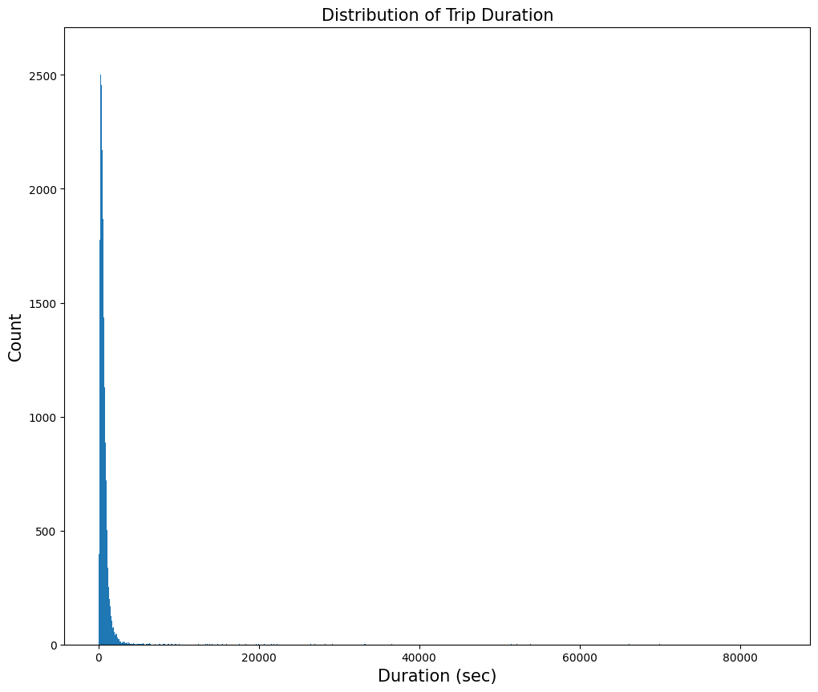

```python
# histogram plot displaying bike trips
binsize = 10
bins = np.arange(0, ford_gobike_clean['duration_sec'].max()+binsize, binsize)

plt.figure(figsize=[12, 10])
plt.hist(data = ford_gobike_clean, x = 'duration_sec', bins = bins)
x_y_t('Duration (sec)','Count','Distribution of Trip Duration')
plt.show()
```

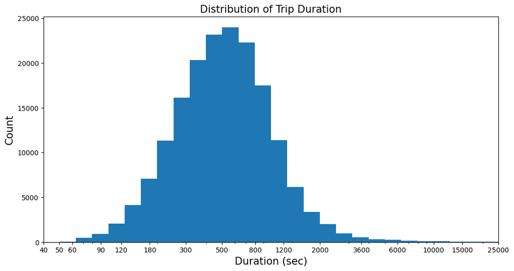

```python
# logarthmic scale transformation on a histogram
# there's a long tail in the distribution, so i'll be using a log scale to deep dive
log_binsize = 0.1
log_bins = 10 ** np.arange(0.0, np.log10(ford_gobike_clean['duration_sec'].max()) + log_binsize, log_binsize)

plt.figure(figsize=[12, 6])
plt.hist(data = ford_gobike_clean, x = 'duration_sec', bins = log_bins)
x_y_t('Duration (sec)','Count','Distribution of Trip Duration')
plt.xscale('log')
tick_locs = [40,50,60,90,120,180,300,500,800,1200,2000,3600,6000,10000,15000,25000]
plt.xticks(tick_locs, tick_locs)
plt.xlim([40,25000])
plt.show()
```

The logarithm scale shows that this distibution is unimodal, peaking around the 500 to 700 seconds range. While a signinicant number of the bike rides lasted round the 300 to 900 sec range, there was not a lot around the 180 sec mark and over the 2000 sec mark.

# Total Number by User-Type

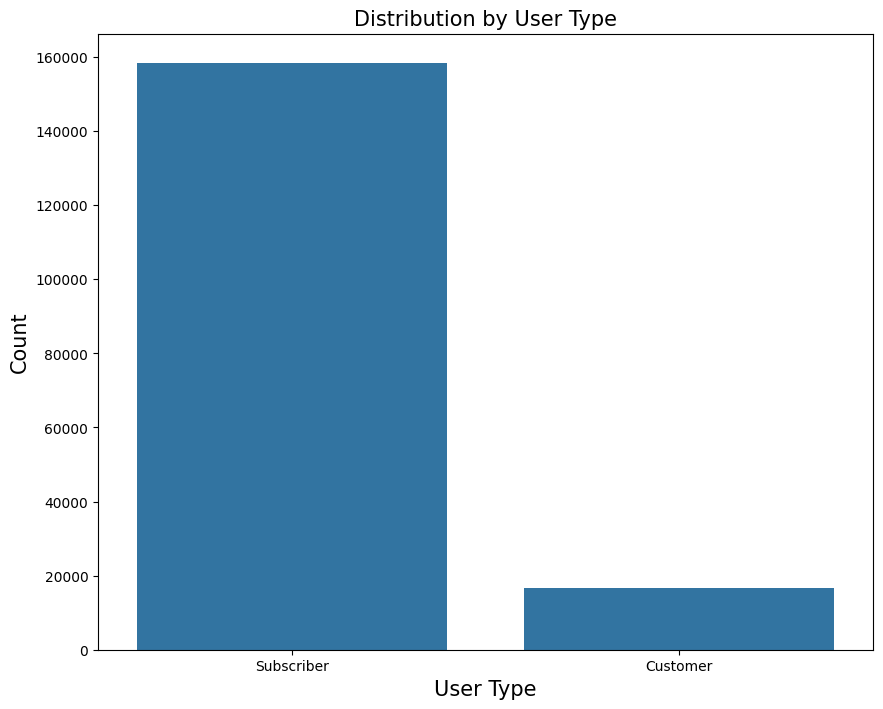

```python
# plot a bar chart
plt.figure(figsize=[10, 8])
user_ind = ford_gobike_clean['user_type'].value_counts().index
sb.countplot(data = ford_gobike_clean, x = 'user_type', order = user_ind, color=base_color)
x_y_t('User Type','Count','Distribution by User Type')
plt.show()
```

The bar chart clearly shows that majority of the bike was rode by subscribers - around 160000 subscribers, which is nearly 10 times that of the customers.

# Distribution by Gender

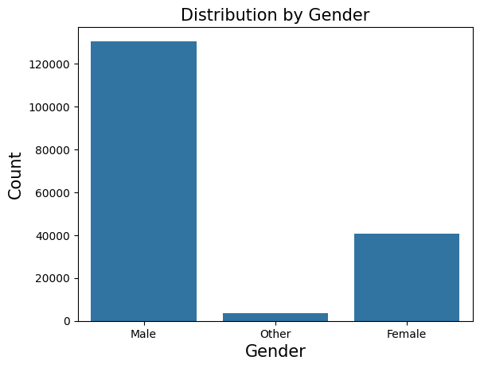

```python
# barplot of gender
sb.countplot(data = ford_gobike_clean, x = 'gender', color=base_color);
x_y_t('Gender','Count','Distribution by Gender')
```

The bar chart clearly shows that most users were Men - above 120000 Men, while about one-third were Women and the users in the other category recorded the lowest number.

# Distribution by Age

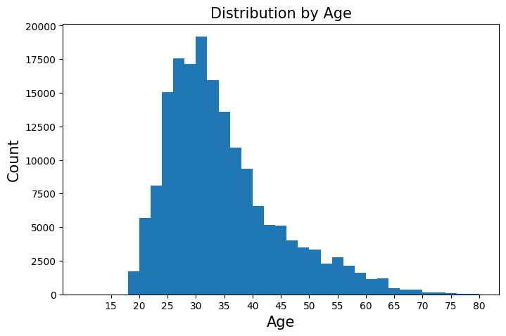

```python
# Plotting age distribution

bins=np.arange(10,80+2,2)
plt.figure(figsize=[8,5])
plt.hist(data=ford_gobike_clean,x='age',bins=bins)
plt.xticks(np.arange(15,85,5))
x_y_t('Age','Count','Distribution by Age')
```

The histogram above clearly shows that there was a significant increase in users at the age of 25 and a steady decrease in the numer of users from around the age of 35 years upward.

## Bivariate Exploration

# Correlation between Duration and Age

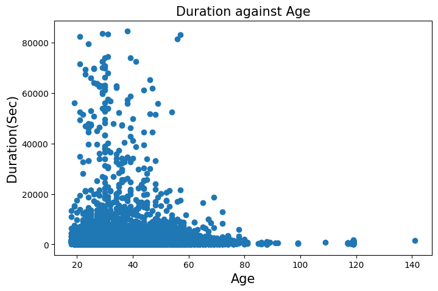

```python
# scatter plot showing distribution between age and trip duration
plt.figure(figsize=[8,5])
plt.scatter(data=ford_gobike_clean,x='age',y='duration_sec')
x_y_t('Age','Duration(Sec)','Duration against Age')
```

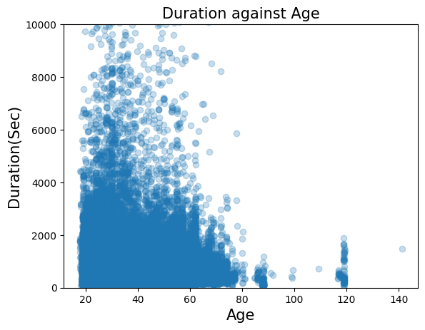

```python
sb.regplot(data=ford_gobike_clean,x='age',y='duration_sec',fit_reg=False, x_jitter=0.3, scatter_kws={'alpha':1/4})
plt.ylim([0,10000])
x_y_t('Age','Duration(Sec)','Duration against Age')
```

The plot above shows there is a weak negative correlation between the duration and age of the user. It's visible that older users have shorter trip duration.

# Relationship between Duration and Gender

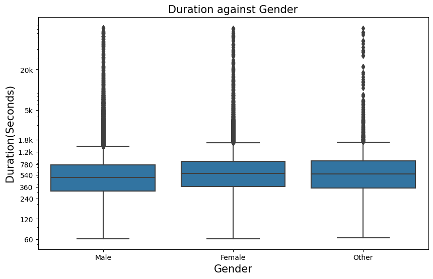

```python
# boxplot showing the relationship
plt.figure(figsize=[10,6])
sb.boxplot(data=ford_gobike_clean,x='gender',y='duration_sec',color=base_color,order=['Male','Female','Other'])
plt.yscale('log')
y_tick=[60,120,240,360,540,780,1.2e3,1.8e3,5e3,20e3]
y_ticklabels=['60','120','240','360','540','780','1.2k','1.8k','5k','20k']
plt.yticks(y_tick,y_ticklabels)
x_y_t('Gender','Duration(Seconds)','Duration against Gender')
```

The box plot above clearly shows that male users had the shortest average trip duration of the three genders, with the Female and Other genders being marginally close.

# Relationship between Duration and User type

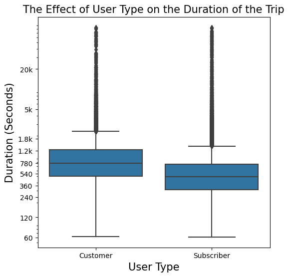

```python
plt.figure(figsize=[6,6])
sb.boxplot(data=ford_gobike_clean,x='user_type',y='duration_sec',color=base_color)
plt.yscale('log')
y_tick=[60,120,240,360,540,780,1.2e3,1.8e3,5e3,20e3]
y_ticklabels=['60','120','240','360','540','780','1.2k','1.8k','5k','20k']
plt.yticks(y_tick,y_ticklabels)
x_y_t('User Type','Duration (Seconds)','The Effect of User Type on the Duration of the Trip')
```

The above box plot shows that the customers rode the bike longer than the subscribers.

# Daily Ride Durations

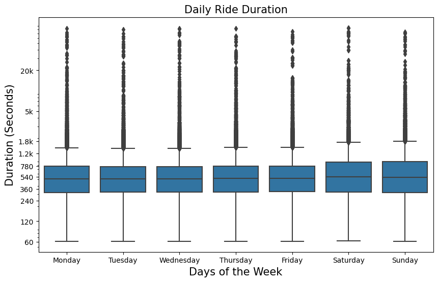

```python
plt.figure(figsize=[10,6])
sb.boxplot(data=ford_gobike_clean,x='start_day_id',y='duration_sec',color=base_color)
plt.yscale('log')
plt.xticks([0,1,2,3,4,5,6],['Monday', 'Tuesday','Wednesday','Thursday','Friday','Saturday', 'Sunday']);
y_tick=[60,120,240,360,540,780,1.2e3,1.8e3,5e3,20e3];
y_ticklabels=['60','120','240','360','540','780','1.2k','1.8k','5k','20k'];
plt.yticks(y_tick,y_ticklabels);
x_y_t('Days of the Week','Duration (Seconds)','Daily Ride Duration')
```

The box plot above clearly shows that the users rode the bike longer on weekends than weekdays.

# Relationship between User Type and Age

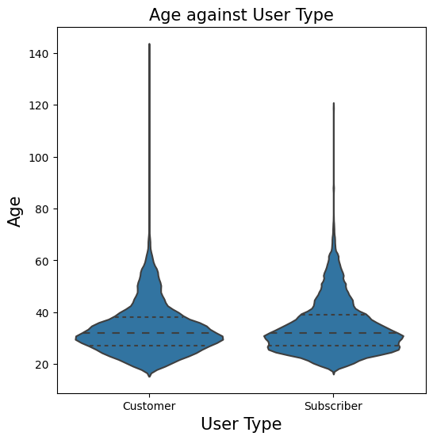

```python
plt.figure(figsize=[6,6])
sb.violinplot(data=ford_gobike_clean,x='user_type',y='age',color=base_color,inner='quartile')
x_y_t('User Type','Age','Age against User Type')
```

The violin plot above shows that there is no relationship between the age and the type of user

### Talk about some of the relationships you observed in this part of the investigation. How did the feature(s) of interest vary with other features in the dataset?

```
- The trip duration is inversely proportional to the age. The older the user, the sorter the trip and vice versa.
- The female and other gender had marginally longer trip duration than the male gender.
- The customers rode the bike for a longer duration than the subscribers.
- The weekend bike ride had longer duration than the weekdays.
```

### Did you observe any interesting relationships between the other features (not the main feature(s) of interest)?

```
- It was surprising that although the total count of male gender was significantly higher than the other genders, it had the shortest trip duration.
- It's also interesting that the customers had longer trips than the subscribers.
```

## Multivariate Exploration

# Gender, Age and Duration

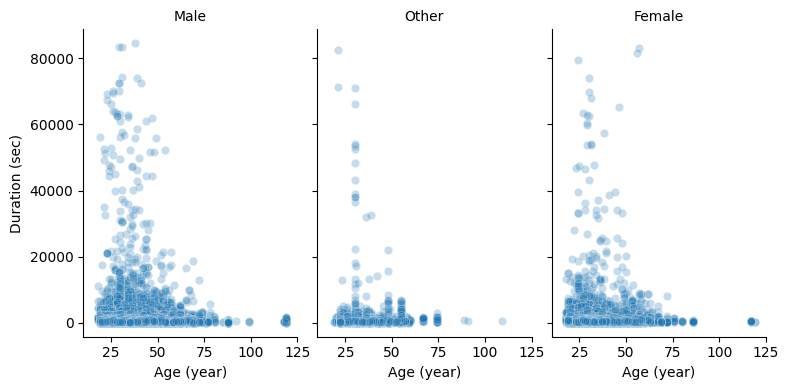

```python
plt.figure(figsize=[15,10])
g = sb.FacetGrid(data = ford_gobike_clean, col = 'gender', col_wrap = 3, height = 4, aspect =0.65,xlim = [10, 125]);
g.map(sb.scatterplot, 'age','duration_sec', alpha= 1/4);
g.set_titles('{col_name}');
#plt.yticks([60,120,240,360,540,780,1.2e3,1.8e3,5e3,20e3],['60','120','240','360','540','780','1.2k','1.8k','5k','20k']);
g.set_axis_labels('Age (year)', 'Duration (sec)');
g.add_legend();
plt.show();
```

From the male gender, most of the data falls around the age of 25 and 75, same goes for the female gender, with the other gender just being a little above the 50 year mark. Interestingly, it is obvious that although majority of the male and female duration is below 20000 secs, there are relatively fewer users within 25 and 75 years with higher bike duration than the male, with the other gender recording the least.